# NOAA Storm Database analysis: Coursera Reproducible Research Project 2

Gustavo Recio

06 December, 2017

# Synopsis

Severe weather conditions are known to be the cause of public concern and economic consequences.

The aim of this project is to explore the U.S. National Oceanic and Atmospheric Administration’s (NOAA) storm database, which tracks several characteristics of weather events in the United States, including their location, date, and their consequences, such as personal injuries and property damage.

As part of this report we will address the following questions:

1. Across the United States, which types of events (as indicated in the EVTYPE variable) are most harmful with respect to population health?
2. Across the United States, which types of events have the greatest economic consequences?

After aggregating the data by type of event, we can see the following outcomes:

1. For the public health (both for injuries and fatalities), tornados cause the biggest damage
2. In terms of economic consequences, floods cause the biggest repercussions

# Data processing

Downloading the data source:

```r
destFile <- "storm-data.csv.bz2"
fileURL <- "https://d396qusza40orc.cloudfront.net/repdata%2Fdata%2FStormData.csv.bz2"
if (!file.exists(destFile)) {
    download.file(fileURL, destFile, method="auto")
}
```

Loading the file into a data frame

```r
sourceData <- read.csv(bzfile(destFile), sep=",", header = TRUE)
```

Initial analysis of the data

```r
names(sourceData)
```

```
##  [1] "STATE__"    "BGN_DATE"   "BGN_TIME"   "TIME_ZONE"  "COUNTY"
##  [6] "COUNTYNAME" "STATE"      "EVTYPE"     "BGN_RANGE"  "BGN_AZI"
## [11] "BGN_LOCATI" "END_DATE"   "END_TIME"   "COUNTY_END" "COUNTYENDN"
## [16] "END_RANGE"  "END_AZI"    "END_LOCATI" "LENGTH"     "WIDTH"
## [21] "F"          "MAG"        "FATALITIES" "INJURIES"   "PROPDMG"
## [26] "PROPDMGEXP" "CROPDMG"    "CROPDMGEXP" "WFO"        "STATEOFFIC"
## [31] "ZONENAMES"  "LATITUDE"   "LONGITUDE"  "LATITUDE_E" "LONGITUDE_"
## [36] "REMARKS"    "REFNUM"
```

```r
head(sourceData)
```

```
##   STATE__           BGN_DATE BGN_TIME TIME_ZONE COUNTY COUNTYNAME STATE
## 1       1  4/18/1950 0:00:00     0130       CST     97     MOBILE    AL
## 2       1  4/18/1950 0:00:00     0145       CST      3    BALDWIN    AL
## 3       1  2/20/1951 0:00:00     1600       CST     57    FAYETTE    AL
## 4       1   6/8/1951 0:00:00     0900       CST     89    MADISON    AL
## 5       1 11/15/1951 0:00:00     1500       CST     43    CULLMAN    AL
## 6       1 11/15/1951 0:00:00     2000       CST     77 LAUDERDALE    AL
##    EVTYPE BGN_RANGE BGN_AZI BGN_LOCATI END_DATE END_TIME COUNTY_END
## 1 TORNADO         0                                               0
## 2 TORNADO         0                                               0
## 3 TORNADO         0                                               0
## 4 TORNADO         0                                               0
## 5 TORNADO         0                                               0
## 6 TORNADO         0                                               0
##   COUNTYENDN END_RANGE END_AZI END_LOCATI LENGTH WIDTH F MAG FATALITIES
```

[output cut: 20 more lines]

Not all the columns in the dataframe are relevant to answer the current query. Removing unused columns

```r
interestingVariables = c('EVTYPE', 'FATALITIES', 'INJURIES', 'PROPDMG', 'PROPDMGEXP', 'CROPDMG', 'CROPDMGEXP')
subsetData <- select(sourceData, interestingVariables)
names(subsetData)
```

```
## [1] "EVTYPE"     "FATALITIES" "INJURIES"   "PROPDMG"    "PROPDMGEXP"
## [6] "CROPDMG"    "CROPDMGEXP"
```

Entries in the variables PROPDMG and CROPDMG are not directly processable, as they have different units. They need to be preprocessed

```r
preprocessedData <- subsetData %>%
  mutate(PROPDMG_SAME_UNIT =
            if_else(PROPDMGEXP == 'H', PROPDMG * 10^2,
            if_else(PROPDMGEXP == 'K', PROPDMG * 10^3,
            if_else(PROPDMGEXP == 'M', PROPDMG * 10^6,
            if_else(PROPDMGEXP == 'B', PROPDMG * 10^9,
            0))))) %>%
  mutate(CROPDMG_SAME_UNIT =
            if_else(CROPDMGEXP == 'H', CROPDMG * 10^2,
            if_else(CROPDMGEXP == 'K', CROPDMG * 10^3,
            if_else(CROPDMGEXP == 'M', CROPDMG * 10^6,
            if_else(CROPDMGEXP == 'B', CROPDMG * 10^9,
            0)))))
```

# Results

## Across the United States, which types of events (as indicated in the EVTYPE variable) are most harmful with respect to population health?

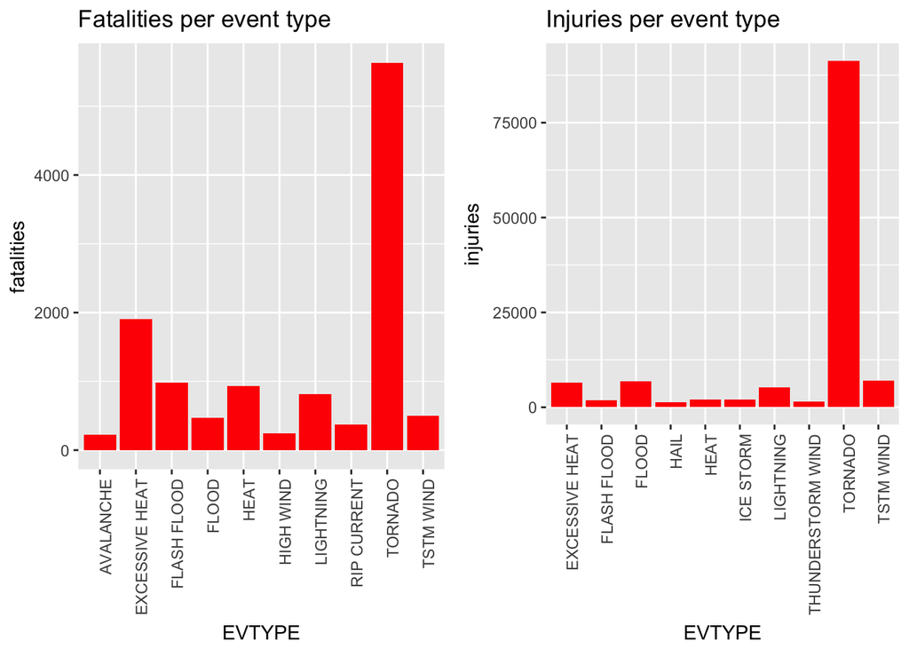

```r
fatalities <- preprocessedData %>%
  group_by(EVTYPE) %>%
  summarize(TOTAL_FATALITIES = sum(FATALITIES, na.rm = TRUE)) %>%
  arrange(desc(TOTAL_FATALITIES)) %>%
  filter(row_number() <= 10)

fatalitiesPlot <- ggplot(fatalities, aes(x = EVTYPE, y = TOTAL_FATALITIES)) +
  geom_bar(stat = "identity", fill = "red") +
  theme(axis.text.x = element_text(angle = 90, hjust = 1)) +
  ylab("fatalities") +
  ggtitle("Fatalities per event type")


injuries <- preprocessedData %>%
  group_by(EVTYPE) %>%
  summarize(TOTAL_INJURIES = sum(INJURIES, na.rm = TRUE)) %>%
  arrange(desc(TOTAL_INJURIES)) %>%
  filter(row_number() <= 10)

injuriesPlot <- ggplot(injuries, aes(x = EVTYPE, y = TOTAL_INJURIES)) +
  geom_bar(stat = "identity", fill = "red") +
  theme(axis.text.x = element_text(angle = 90, hjust = 1)) +
  ylab("injuries") +
  ggtitle("Injuries per event type")


# Multiplot function copied from: http://www.cookbook-r.com/Graphs/Multiple_graphs_on_one_page_(ggplot2)/
multiplot(fatalitiesPlot, injuriesPlot, cols=2)
```

## Across the United States, which types of events have the greatest economic consequences?

First, let’s explore the property and crop damage separatedly

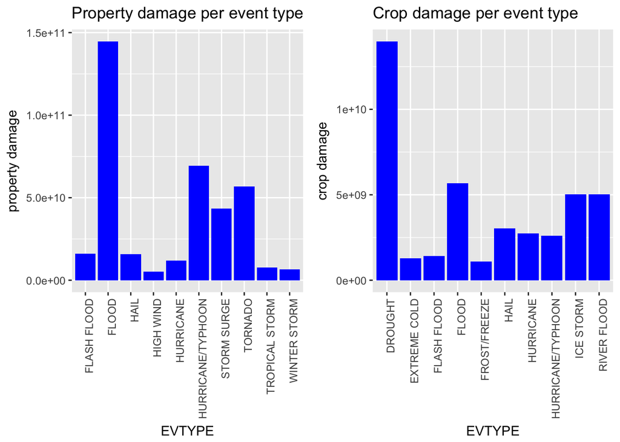

```r
propertyDamage <- preprocessedData %>%
  group_by(EVTYPE) %>%
  summarize(TOTAL_PROP_DMG = sum(PROPDMG_SAME_UNIT, na.rm = TRUE)) %>%
  arrange(desc(TOTAL_PROP_DMG))


propertyDamagePlot <- ggplot(filter(propertyDamage, row_number() <= 10), aes(x = EVTYPE, y = TOTAL_PROP_DMG)) +
  geom_bar(stat = "identity", fill = "blue") +
  theme(axis.text.x = element_text(angle = 90, hjust = 1)) +
  ylab("property damage") +
  ggtitle("Property damage per event type")


cropDamage <- preprocessedData %>%
  group_by(EVTYPE) %>%
  summarize(TOTAL_CROP_DMG = sum(CROPDMG_SAME_UNIT, na.rm = TRUE)) %>%
  arrange(desc(TOTAL_CROP_DMG))

cropDamagePlot <- ggplot(filter(cropDamage, row_number() <= 10), aes(x = EVTYPE, y = TOTAL_CROP_DMG)) +
  geom_bar(stat = "identity", fill = "blue") +
  theme(axis.text.x = element_text(angle = 90, hjust = 1)) +
  ylab("crop damage") +
  ggtitle("Crop damage per event type")


# Multiplot function copied from: http://www.cookbook-r.com/Graphs/Multiple_graphs_on_one_page_(ggplot2)/
multiplot(propertyDamagePlot, cropDamagePlot, cols=2)
```

```r
totalDamage <- inner_join(propertyDamage, cropDamage) %>%
  mutate(TOTAL_DAMAGE = TOTAL_PROP_DMG + TOTAL_CROP_DMG) %>%
  arrange(desc(TOTAL_PROP_DMG)) %>%
  filter(row_number() <= 10)
```

[figure not shown]

```r
ggplot(filter(totalDamage, row_number() <= 10), aes(x = EVTYPE, y = TOTAL_CROP_DMG)) +
  geom_bar(stat = "identity", fill = "blue") +
  theme(axis.text.x = element_text(angle = 90, hjust = 1)) +
  ylab("Total damage") +
  ggtitle("Total damage")
```